# Kaggle-Predicting Sales

# 1 Introduction

The goal of this study is to predict the future sales for fifty-four different Ecuadorian-based grocery stores of the Corporacian Favorita retail chain. Doing this will allow for the retail chain to better prepare for expected future sales by stocking the shelves with inventory accordingly.

# 2 Libraries

```r
library(dplyr)
library(ggplot2)
library(gt) #neat tables
library(lubridate) #time series functions
library(stringr) #string functions
library(gridExtra) #organizing plots
library(TSstudio) #time series functions like ts_decompose
library(xts) # ts data frame
library(imputeTS) # imputation used for oil prices
library(caret) # modeling
library(Metrics) #rmsle
library(glmnet) #elastic net
library(rlist) #save a list
options(scipen = 999) # removes scientific notation
```

# 3 Importing Data

The data used for this study comes from five different data frames.

```r
oil <- read.csv("oil.csv",stringsAsFactors = FALSE)
stores <- read.csv("stores.csv",stringsAsFactors = FALSE)
transactions <- read.csv("transactions.csv",stringsAsFactors = FALSE)
train <- read.csv("train.csv",stringsAsFactors = FALSE)
test <- read.csv("test.csv",stringsAsFactors = FALSE)
holidays <- read.csv("holidays_events.csv",stringsAsFactors = FALSE)
# Holidays is excluded from this study for times sake
```

## 3.1 Oil

The oil data set contains 1218 observations and 2 variables:

**date:** Ranges from January 1st, 2013 to August 31, 2017.

**dcoilwtico:** The daily oil price for that day.

```r
gt(head(oil))
```

| date | dcoilwtico |
| --- | --- |
| 2013-01-01 | NA |
| 2013-01-02 | 93.14 |
| 2013-01-03 | 92.97 |
| 2013-01-04 | 93.12 |
| 2013-01-07 | 93.20 |
| 2013-01-08 | 93.21 |

## 3.2 Stores

The stores data set contains 54 observations and 5 variables:

**store_nbr:** Specific store number ranging from one to fifty-four.

**city:** City where store is located.

**state:** State where store is located.

**type:** Type of store grouped into five categories: A, B, C, D, or E.

**cluster:** Grouping of similar stores, seventeen possible groups.

```r
gt(head(stores))
```

| store_nbr | city | state | type | cluster |
| --- | --- | --- | --- | --- |
| 1 | Quito | Pichincha | D | 13 |
| 2 | Quito | Pichincha | D | 13 |
| 3 | Quito | Pichincha | D | 8 |
| 4 | Quito | Pichincha | D | 9 |
| 5 | Santo Domingo | Santo Domingo de los Tsachilas | D | 4 |
| 6 | Quito | Pichincha | D | 13 |

## 3.3 Transactions

The transactions data set contains 83,488 observations and 3 variables:

**date:** Ranging from January 1st, 2013 to August 15th, 2017.

**store_nbr:** The unique identifier for store number.

**transactions:** The number of transactions made.

```r
gt(head(transactions))
```

| date | store_nbr | transactions |
| --- | --- | --- |
| 2013-01-01 | 25 | 770 |
| 2013-01-02 | 1 | 2111 |
| 2013-01-02 | 2 | 2358 |
| 2013-01-02 | 3 | 3487 |
| 2013-01-02 | 4 | 1922 |
| 2013-01-02 | 5 | 1903 |

## 3.4 Train

The train data set contains 3,000,888 observations and 6 variables:

**id:** Unique id for each observation.

**date:** Ranging from January 1st, 2013 to August 15th, 2017.

**store_nbr:** fifty-four stores.

**family:** Deparment in store.

**sales:** Daily sales for each family.

**onpromotion:** Total number of products in a family that were being promoted that day.

```r
gt(head(train))
```

| id | date | store_nbr | family | sales | onpromotion |
| --- | --- | --- | --- | --- | --- |
| 0 | 2013-01-01 | 1 | AUTOMOTIVE | 0 | 0 |
| 1 | 2013-01-01 | 1 | BABY CARE | 0 | 0 |
| 2 | 2013-01-01 | 1 | BEAUTY | 0 | 0 |
| 3 | 2013-01-01 | 1 | BEVERAGES | 0 | 0 |
| 4 | 2013-01-01 | 1 | BOOKS | 0 | 0 |
| 5 | 2013-01-01 | 1 | BREAD/BAKERY | 0 | 0 |

## 3.5 Test

The test set is where our final predictions will be made. Contains 28,512 observations and 5 variables:

**id:** Unique identifier.

**date:** Ranging from August 16th, 2017 to August 31st, 2017.

**store_nbr:** Fifty-four stores.

**family:** Department of store, thirty-three possible values.

**onpromotion:** Number of items on promotion for a given family for that day.

```r
gt(head(test))
```

| id | date | store_nbr | family | onpromotion |
| --- | --- | --- | --- | --- |
| 3000888 | 2017-08-16 | 1 | AUTOMOTIVE | 0 |
| 3000889 | 2017-08-16 | 1 | BABY CARE | 0 |
| 3000890 | 2017-08-16 | 1 | BEAUTY | 2 |
| 3000891 | 2017-08-16 | 1 | BEVERAGES | 20 |
| 3000892 | 2017-08-16 | 1 | BOOKS | 0 |
| 3000893 | 2017-08-16 | 1 | BREAD/BAKERY | 12 |

## 3.6 Combining Datasets

In order for easier data analysis the data sets will be combined.

```r
train <- left_join(train,transactions,by=c("date"="date","store_nbr"="store_nbr"))

train <- left_join(train,stores,by=("store_nbr"="store_nbr"))

train <- left_join(train,oil,by=("date"="date"))


train <- train %>% select(-id)
```

```r
test <- left_join(test,stores,by=("store_nbr"="store_nbr"))

test <- left_join(test,oil,by=("date"="date"))
```

# 4 Data Analysis

In order to get the best results from our data we must first understand our data. In this section we will begin breaking down our data to understand what must be accomplished in our feature engineering section.

## 4.1 NA Values

From the data only the oil prices and transactions variables contain NA values. This could represent days where the oil prices were not recorded and days when no transactions were made. Since transactions is not available in the test set, it will not used for our forecasting. Imputation will be used for oil prices in the feature engineering section.

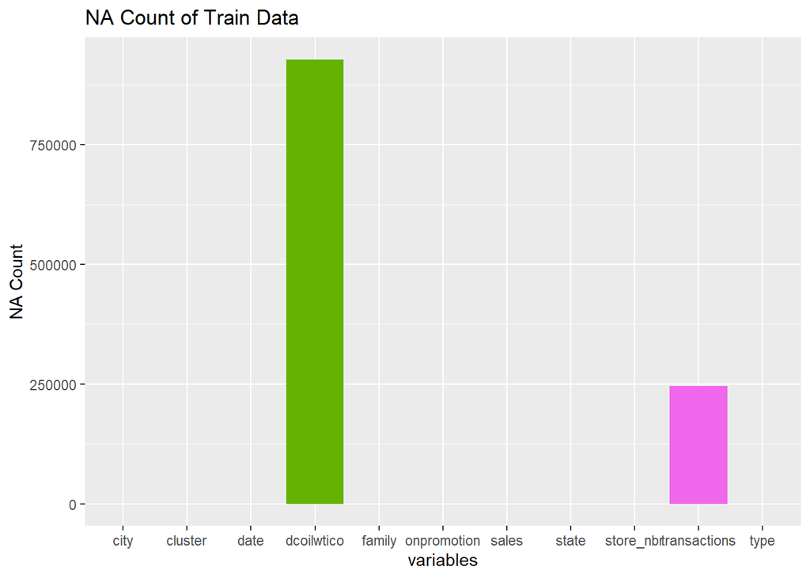

```r
nadf <- data.frame(sapply(train,function(x) sum(is.na(x))))
nadf$variables <- row.names(nadf)
names(nadf)[1] <- "naCount"

ggplot(nadf,aes(x=variables,y=naCount,fill=variables))+
  geom_col()+
  labs(title="NA Count of Train Data")+
  ylab("NA Count")+
  theme(legend.position="none")
```

```r
rm(nadf)
```

## 4.2 Sales

The sales seem to exhibit a positive trend every year. There is a seasonal pattern with December having the highest sales each year.

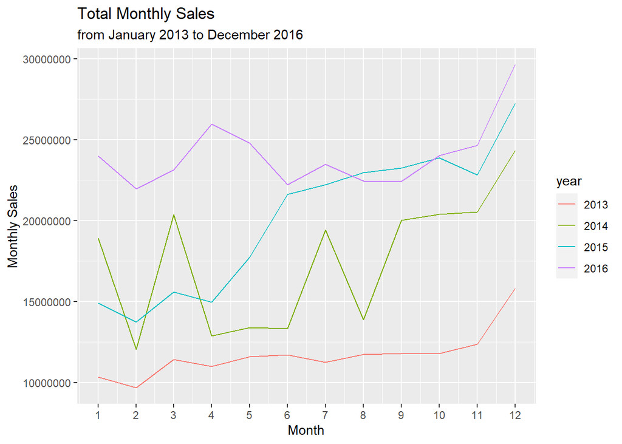

```r
train %>%
  group_by(month=month(date),year=year(date)) %>%
  filter(year %in% c(2013,2014,2015,2016)) %>%
  summarize(monthlySales=sum(sales)) %>%
  ggplot(.,aes(x=month,y=monthlySales))+
  geom_line(aes(color=as.factor(year)))+
  labs(title="Total Monthly Sales",
       subtitle="from January 2013 to December 2016")+
  xlab("Month")+
  ylab("Monthly Sales")+
  scale_x_continuous(breaks = seq(1, 12, by = 1))+
  guides(color=guide_legend(title="year"))
```

On Kaggle it mentioned that the first and fifteenth of every month was payday. It appears there might be some relationship with average sales and the day of the month.

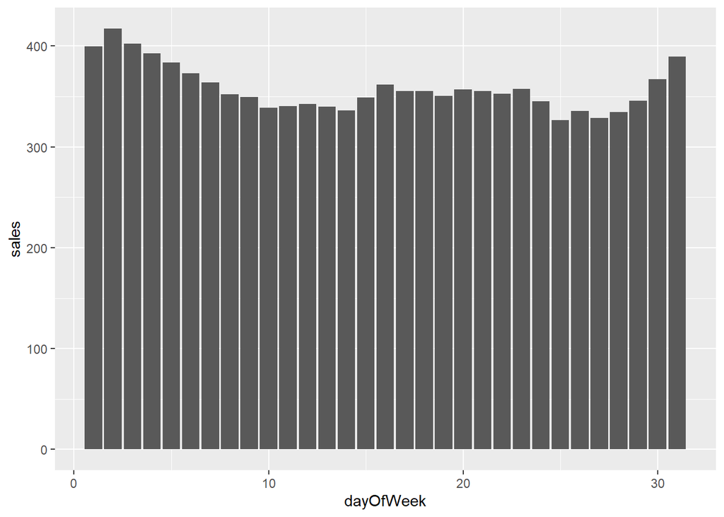

```r
train %>% group_by(dayOfWeek=day(date)) %>%
  summarize(sales=mean(sales)) %>%
  ggplot(.,aes(x=dayOfWeek,y=sales))+
  geom_col()
```

Weekends have higher average sales than week days.

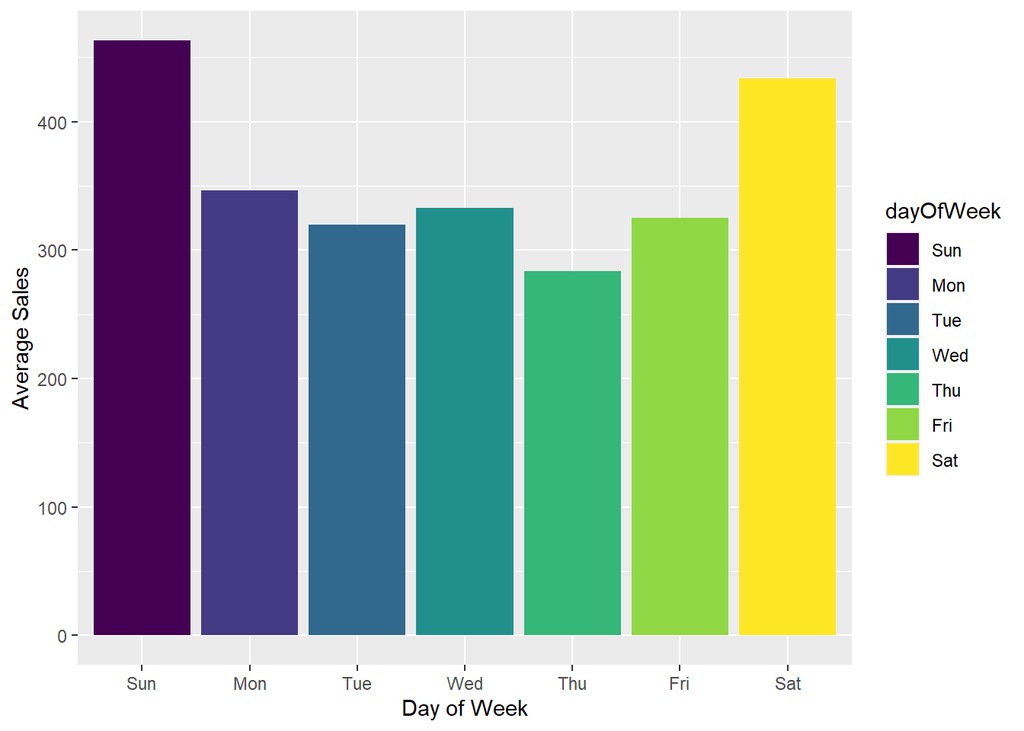

```r
train %>%
  mutate(dayOfWeek=wday(ymd(date),label=TRUE)) %>%
  group_by(dayOfWeek) %>%
  summarize(averageSales=mean(sales)) %>%
  ggplot(.,aes(x=as.factor(dayOfWeek),y=averageSales))+
  geom_col(aes(fill=dayOfWeek))+
  xlab("Day of Week")+
  ylab("Average Sales")
```

## 4.3 Predictors

**Store Number**

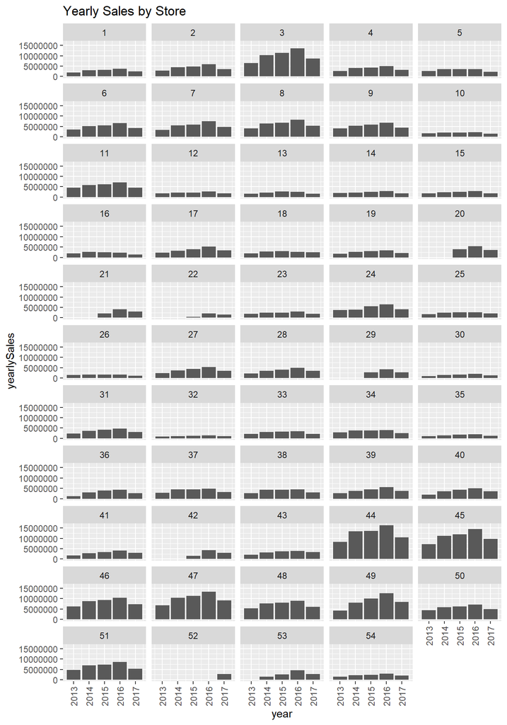

```r
train %>%
  group_by(store_nbr=store_nbr,year=year(date)) %>%
  summarize(yearlySales=sum(sales,na.rm=TRUE)) %>%
  ggplot(.,aes(x=year,y=yearlySales))+
  geom_col()+
  labs(title="Yearly Sales by Store")+
  theme(axis.text.x = element_text(angle = 90, vjust = 0.5, hjust=1))+
  facet_wrap(~store_nbr,ncol=5)
```

**Family**

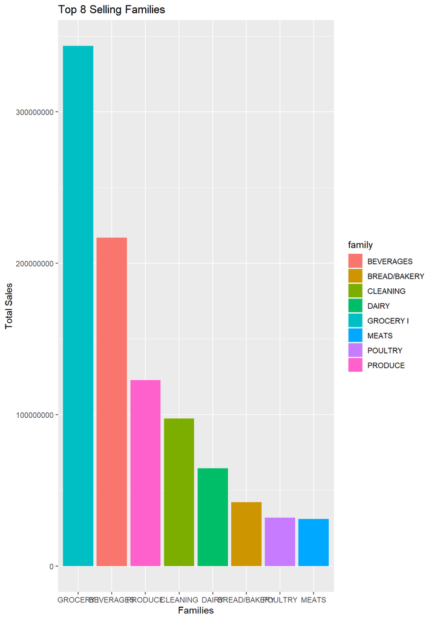

```r
train %>%
  group_by(family) %>%
  summarize(totalSales=sum(sales)) %>%
  arrange(desc(totalSales)) %>%
  head(8) %>%
  ggplot(.,aes(x=reorder(family,desc(totalSales)),y=totalSales,fill=family))+
  geom_col()+
  labs(title="Top 8 Selling Families")+
  xlab("Families")+
  ylab("Total Sales")
```

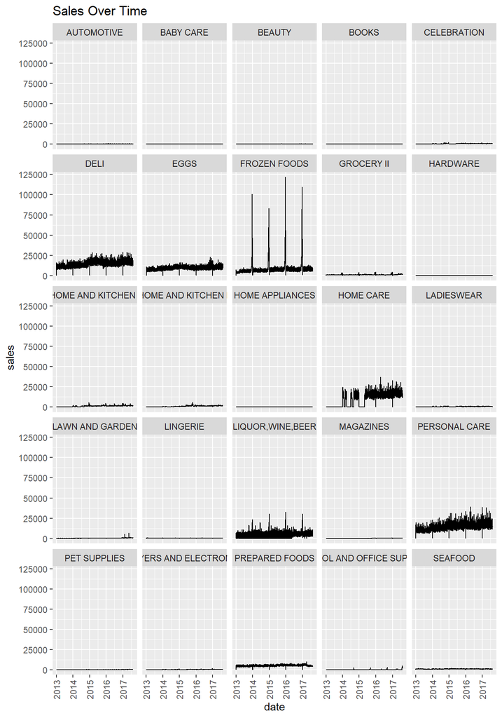

```r
top8 <- c("GROCERY I","BEVERAGES","PRODUCE","CLEANING","DAIRY","BREAD/BAKERY","POULTRY","MEATS")

train %>%
  filter(!family %in% top8) %>%
  group_by(family,date=ymd(date)) %>%
  summarize(sales=sum(sales,na.rm=TRUE)) %>%
  ggplot(.,aes(x=date,y=sales))+
  geom_line()+
  labs(title="Sales Over Time")+
  theme(axis.text.x = element_text(angle = 90, vjust = 0.5, hjust=1))+
  facet_wrap(~family,ncol=5)
```

**Promotion**

All stores that had at least one promotion on a given day had higher average sales than if they did not have a promotion. It also appears the number of promotions on a given day lead to higher sales up to 250 promotions, and then there appears to be a sharp decrease in average sales. Nearly all these instances of over 250 promotions occurred in stores 53 and 54.

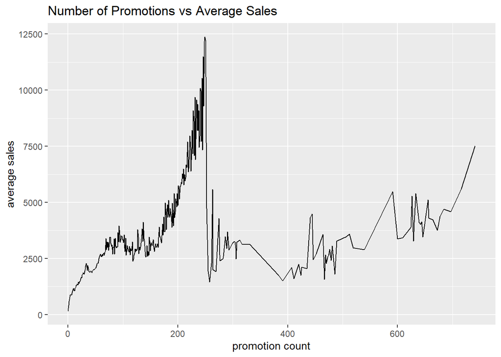

```r
train[complete.cases(train),] %>%
  group_by(onpromotion) %>%
  summarize(meanSales=mean(sales)) %>%
  ggplot(.,aes(x=onpromotion,y=meanSales))+
  geom_line()+
  xlab("promotion count")+
  ylab("average sales")+
  labs(title="Number of Promotions vs Average Sales")
```

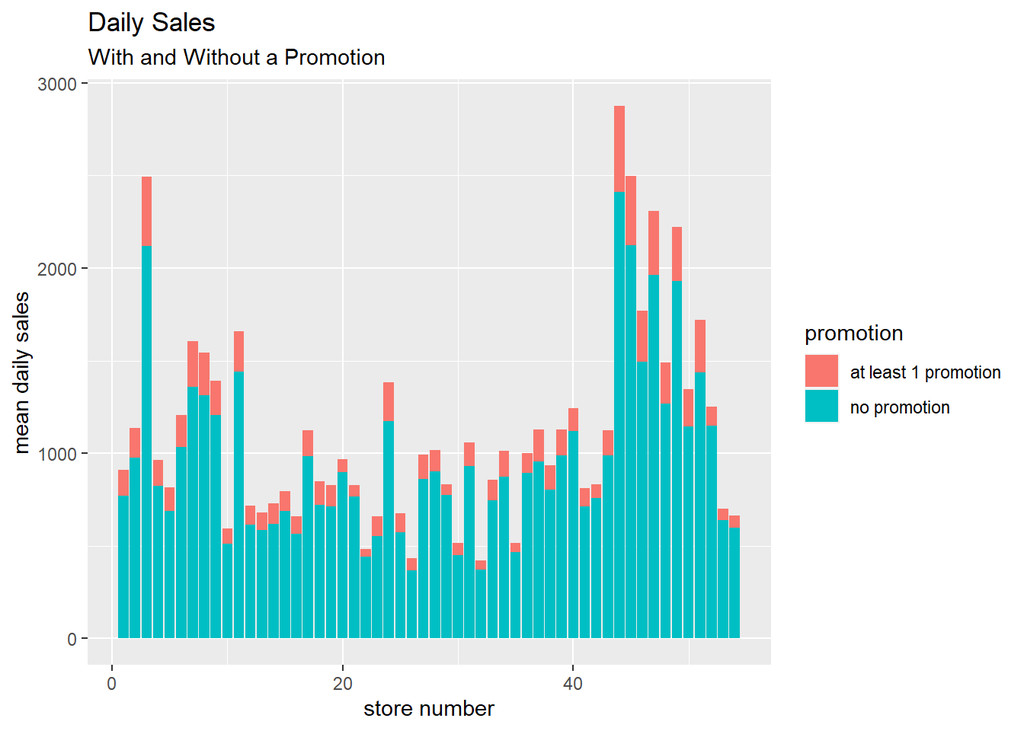

```r
train[complete.cases(train),] %>%
  mutate(hasAPromotion=ifelse(onpromotion>0,1,0)) %>%
  group_by(hasAPromotion,store_nbr) %>%
  summarize(meanSales=mean(sales)) %>%
  ggplot(.,aes(x=store_nbr,y=meanSales,fill=as.factor(hasAPromotion)))+
  geom_col()+
  scale_fill_discrete(labels=c("at least 1 promotion","no promotion"))+
  labs(fill="promotion",
       title="Daily Sales",
       subtitle="With and Without a Promotion")+
  xlab("store number")+
  ylab("mean daily sales")
```

Instances of over 250 daily promotions by store number.

```r
table(as.data.frame(train %>%
  group_by(onpromotion,store_nbr) %>%
  summarize(meanSales=mean(sales)) %>%
  filter(onpromotion>250))$store_nbr)
```

```
##
## 16 33 35 36 49 53 54
##  3  3  4  2  2 69 30
```

**Transactions**

There is a rather weak correlation between the number of transactions and amount of sales. This could be caused from large differences in the price of the items.

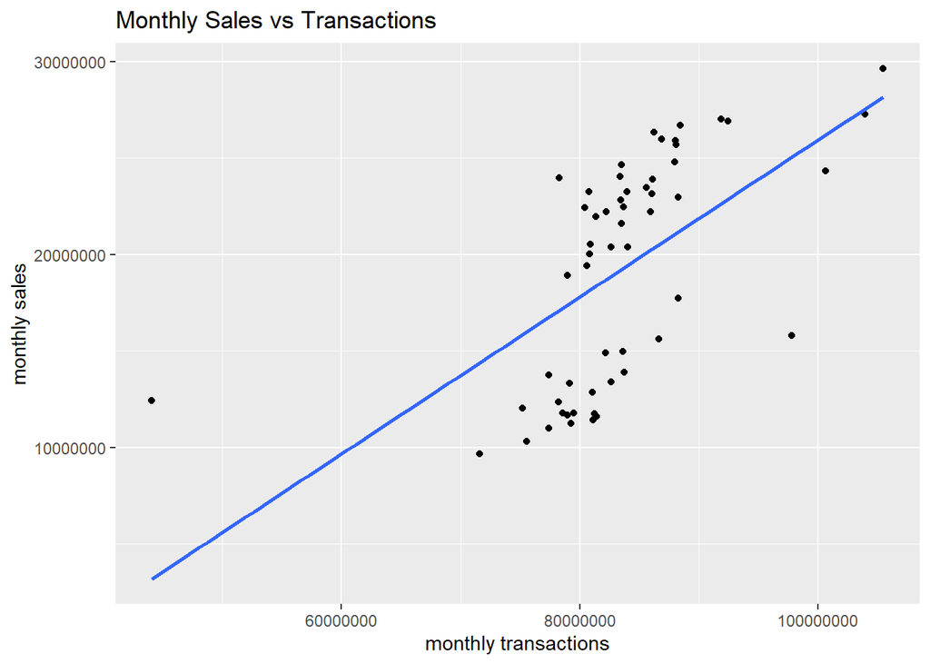

```r
train %>%
  group_by(year=year(date),month=month(date)) %>%
  summarize(monthlySales=sum(sales),monthlyTransactions=sum(transactions,na.rm=TRUE)) %>%
  mutate(date=ym(str_c(year,",",month))) %>%
ggplot(.,aes(x=monthlyTransactions,y=monthlySales))+
  geom_point()+
  geom_smooth(method="lm",se=FALSE)+
  xlab("monthly transactions")+
  ylab("monthly sales")+
  labs(title="Monthly Sales vs Transactions")
```

```r
cor(train$sales,train$transactions,use="complete.obs")
```

```
## [1] 0.2148148
```

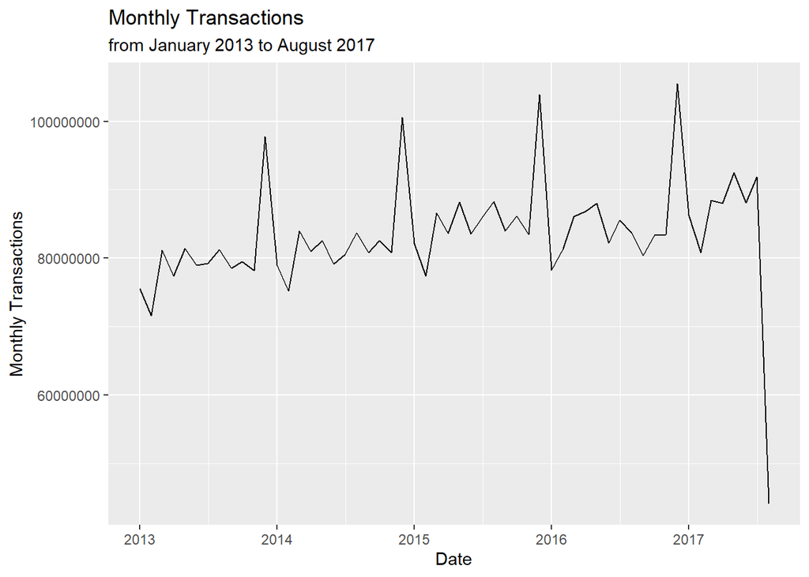

```r
train %>%
  filter(!is.na(transactions)) %>%
  group_by(month=month(date),year=year(date)) %>%
  summarize(monthlyTransactions=sum(transactions)) %>%
  mutate(date=ym(str_c(year,",",month))) %>%
  ggplot(.,aes(x=date,y=monthlyTransactions))+
  geom_line()+
  xlab("Date")+
  ylab("Monthly Transactions")+
  labs(title="Monthly Transactions",
       subtitle="from January 2013 to August 2017")
```

When comparing the transactions vs the sales by individual families we can see that some families have a very high correlation between transactions and sales.

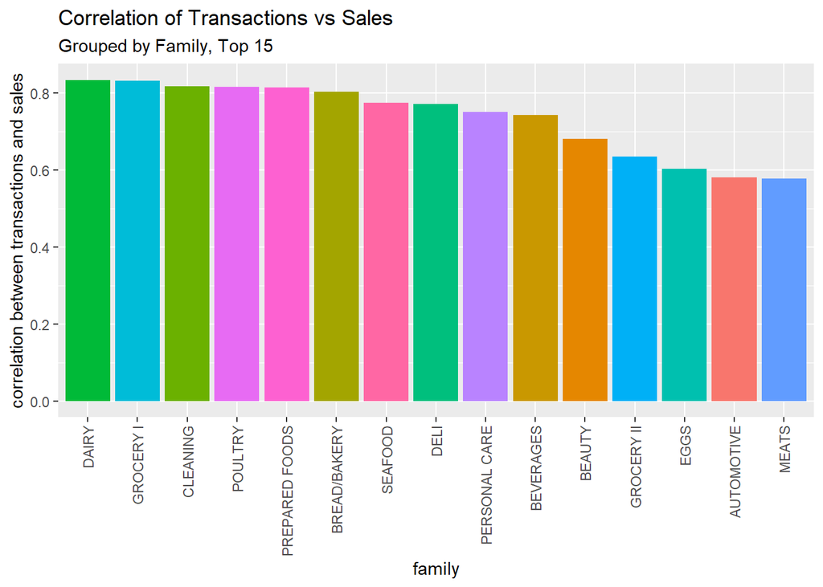

```r
corlist <- list()
for(name in names(table(train$family))){
  temp <- train[train$family==name,] #filter by family

  tempCor <- cor(temp[,"transactions"],temp[,"sales"],use="complete.obs") #cor of trans. and sales for each family

  corlist <- append(corlist,tempCor) #saving cor results
}

byFamily <- data.frame(family=names(table(train$family)),
           correlation=unlist(corlist))


byFamily %>%
  arrange(desc(correlation)) %>%
  head(15) %>%
ggplot(.,aes(x=reorder(family,desc(correlation)),y=correlation)) +
  geom_col(aes(fill=family))+
  ylab("correlation between transactions and sales")+
  xlab("family")+
  labs(title="Correlation of Transactions vs Sales",
       subtitle="Grouped by Family, Top 15")+
  theme(axis.text.x = element_text(angle = 90, vjust = 0.5, hjust=1),
        legend.position="none")
```

```r
rm(byFamily)
```

**City**

There are a total of 22 different cities in the data set. Quito has the largest amount of sales but also contains the highest number of stores. Most cities contain only 1 store.

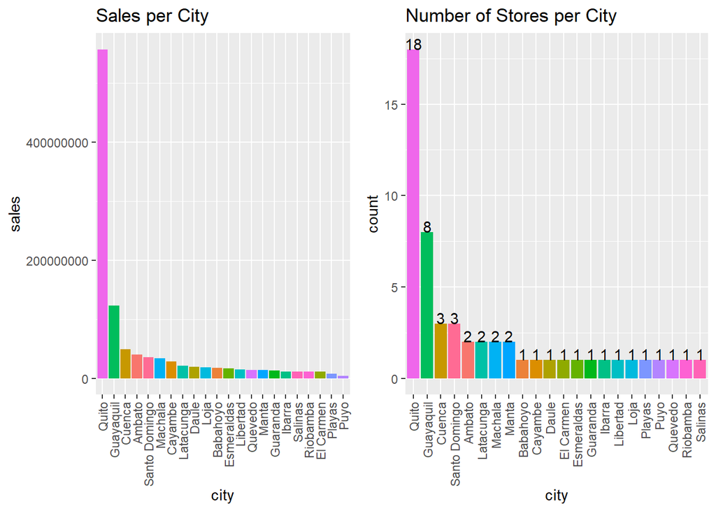

```r
totalCity <- train %>%
  group_by(city=city) %>%
  summarize(sales=sum(sales)) %>%
  ggplot(.,aes(x=reorder(city,desc(sales)),y=sales,fill=city))+
  geom_col()+
  xlab("city")+
  labs(title="Sales per City")+

  theme(axis.text.x = element_text(angle = 90, vjust = 0.5, hjust=1),
        legend.position="none")

countCity <- train %>%
  group_by(city) %>%
  summarize(count=n()) %>%
  mutate(count=count/55572) %>%
  arrange(desc(count)) %>%
  ggplot(.,aes(x=reorder(city,desc(count)),y=count,fill=city))+
  geom_col()+
  xlab("city")+
  ylab("count")+
  labs(title="Number of Stores per City")+
  geom_text(aes(label = count), vjust = 0)+
  theme(legend.position="none",
        axis.text.x = element_text(angle = 90, vjust = 0.5, hjust=1))

grid.arrange(totalCity,countCity,ncol=2)
```

**State**

The stores exist in 16 different states. Pichincha contains 19 of the total 54 stores and also has the highest total sales.

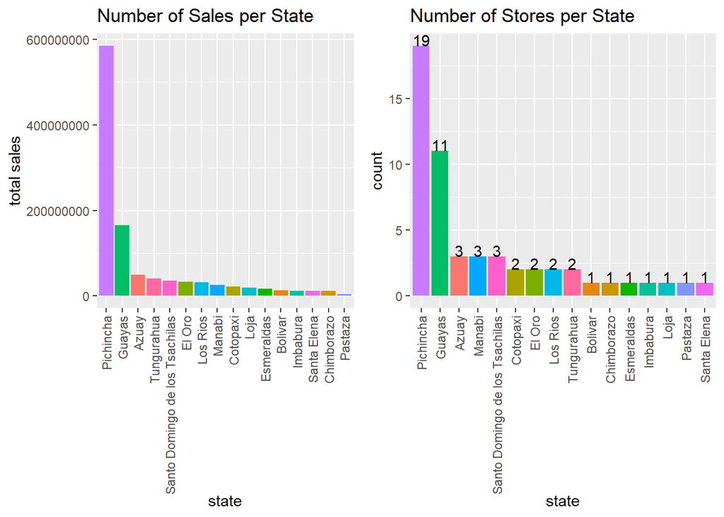

```r
salesState <- train %>%
  group_by(state) %>%
  summarize(totalSales=sum(sales)) %>%
  ggplot(.,aes(x=reorder(state,desc(totalSales)),y=totalSales,fill=state))+
  geom_col()+
  xlab("state")+
  ylab("total sales")+
  labs(title="Number of Sales per State")+
  theme(legend.position="none",
        axis.text.x = element_text(angle = 90, vjust = 0.5, hjust=1))

countState <- train %>%
  group_by(state) %>%
  summarize(count=n()/55572) %>%
  ggplot(.,aes(x=reorder(state,desc(count)),y=count,fill=state))+
  geom_col()+
  geom_text(aes(label = count), vjust = 0)+
  xlab("state")+
  labs(title="Number of Stores per State")+
  theme(legend.position="none",
        axis.text.x = element_text(angle = 90, vjust = 0.5, hjust=1))

grid.arrange(salesState,countState,ncol=2)
```

**Type**

The type of stores labeled “A” have the largest average sales of the 5 different possible types of stores. Most stores are type “D” or type “C”.

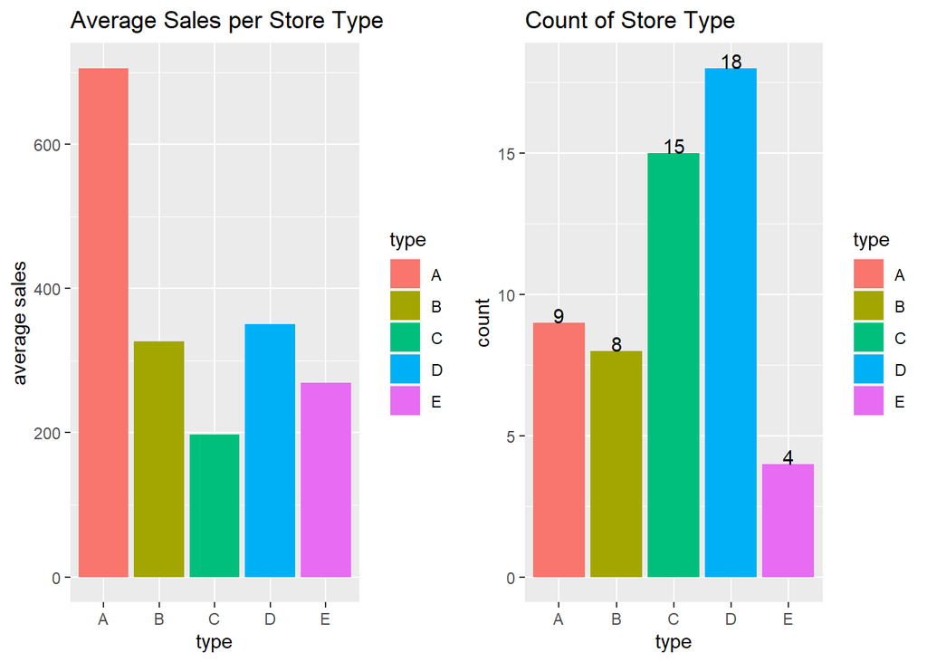

```r
salesType <- train %>% group_by(type) %>%
  summarize(meanSales=mean(sales)) %>%
  ggplot(.,aes(x=type,y=meanSales,fill=type))+
  geom_col()+
  ylab("average sales")+
  labs(title="Average Sales per Store Type")

countType <- train %>%
  group_by(type) %>%
  summarize(count=n()/55572) %>%
  ggplot(.,aes(x=type,y=count,fill=type))+
  geom_col()+
  geom_text(aes(label = count), vjust = 0)+
  labs(title="Count of Store Type")

grid.arrange(salesType,countType,ncol=2)
```

```r
rm(salesType,countType)
```

**Cluster**

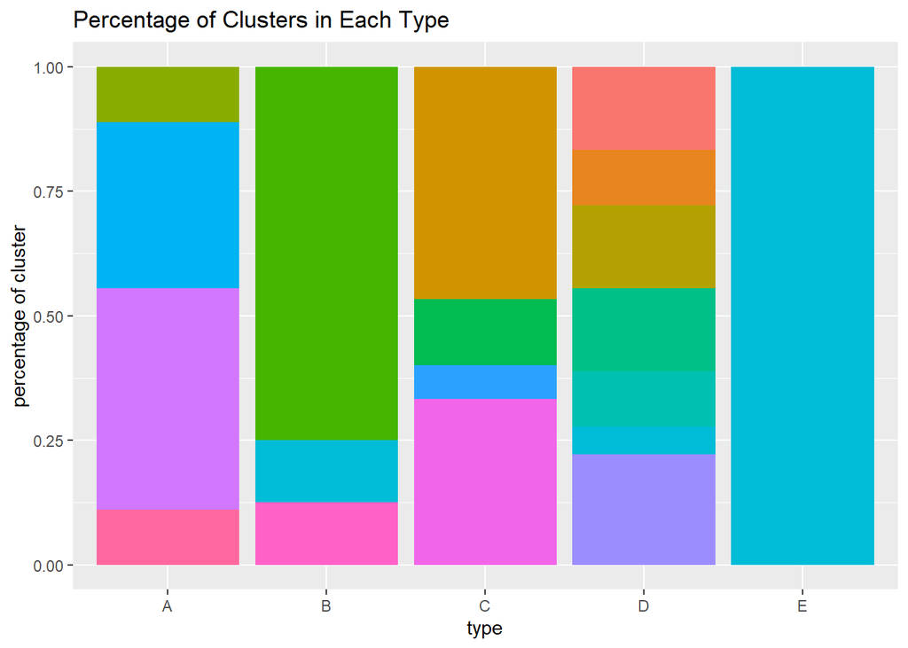

```r
train %>%
  group_by(type,cluster) %>%
  summarize(count=n()/55572) %>%
  ggplot(.,aes(x=type,y=count,fill=as.factor(cluster)))+
  geom_col(position="fill")+
  ylab("percentage of cluster")+
  xlab("type")+
  labs(title="Percentage of Clusters in Each Type")+
  theme(legend.position="none")
```

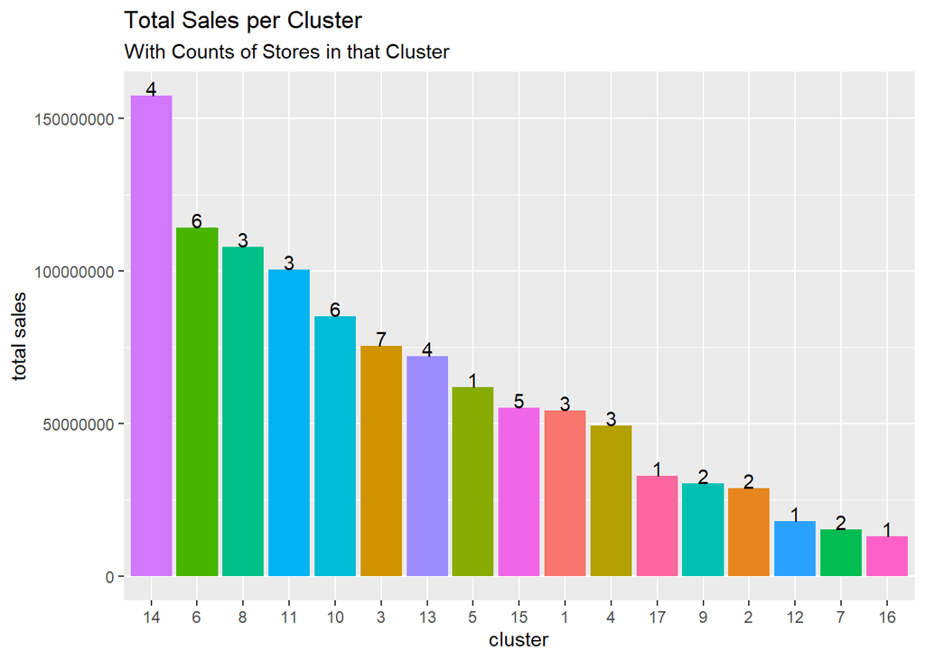

```r
train %>%
  group_by(cluster) %>%
  summarize(totalSales=sum(sales),
            count=n()/55572) %>%
  ggplot(.,aes(x=reorder(cluster,desc(totalSales)),y=totalSales,fill=as.factor(cluster)))+
  geom_col()+
  geom_text(aes(label = count), vjust = 0)+
  xlab("cluster")+
  ylab("total sales")+
  labs(title="Total Sales per Cluster",
       subtitle="With Counts of Stores in that Cluster")+
  theme(legend.position="none")
```

**Oil Prices**

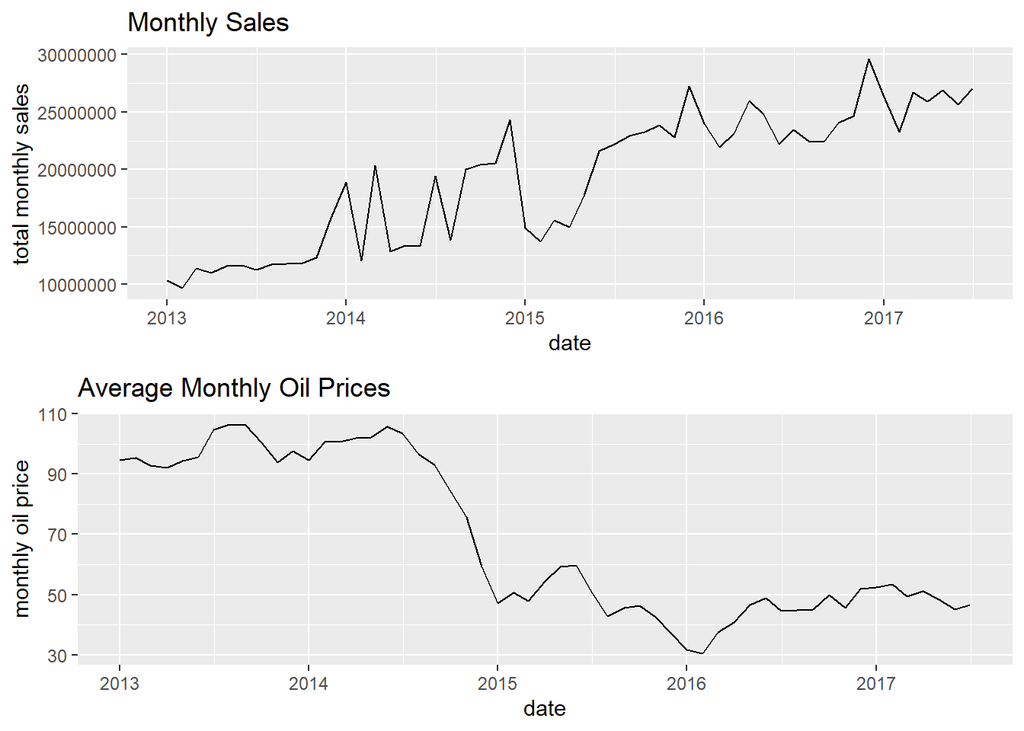

```r
monthlyOilVsSales <- train %>%
  group_by(date) %>%
  summarize(dailySales=sum(sales,na.rm=TRUE)) %>%
  left_join(oil,by=c("date"="date")) %>%
  group_by(month=month(date),year=year(date)) %>%
  summarize(monthlySales=sum(dailySales),
            avgMonthlyOilPrice=mean(dcoilwtico,na.rm=TRUE)) %>%
  mutate(monthlyDate=ym(str_c(year,",",month))) %>%
  filter(monthlyDate<ymd(str_c("2017",",","08",",","1")))

totalMonthlySales <- ggplot(monthlyOilVsSales,aes(x=monthlyDate,y=monthlySales))+
  geom_line()+
  labs(title="Monthly Sales")+
  xlab("date")+
  ylab("total monthly sales")
averageOilPrices <- ggplot(monthlyOilVsSales,aes(x=monthlyDate,y=avgMonthlyOilPrice))+
  geom_line()+
  labs(title="Average Monthly Oil Prices")+
  ylab("monthly oil price")+
  xlab("date")

grid.arrange(totalMonthlySales,averageOilPrices,nrow=2)
```

```r
print(paste("The correlation between sales and oil prices is:",round(cor(monthlyOilVsSales$monthlySales,monthlyOilVsSales$avgMonthlyOilPrice),2)))
```

```
## [1] "The correlation between sales and oil prices is: -0.78"
```

## 4.4 Key Findings:

- Imputation needs to be used for oil prices as the price is not recorded everyday.
- Sales exhibit a positive trend over time.
- Some relationship between day of week and average sales.
- There is a monthly seasonal effect on sales.
- Sales varies widely between stores.
- Each family had a different sales pattern.
- Sales increase when a promotion is present.
- Within families there is a strong correlation between transactions and sales.
- The type of store has a large effect on average sales.
- Oil prices and sales have a strong negative correlation.

# 5 Feature Engineering

## 5.1 Oil Imputation

The na_kalman function from the imputeTS package will be used for imputation on the oil prices.

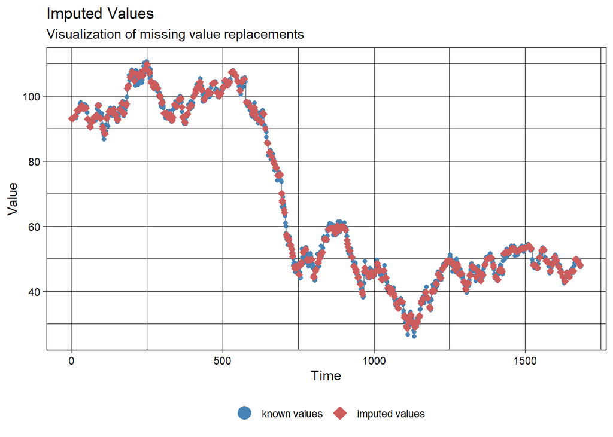

```r
oilPrices <- train %>%
  group_by(date) %>%
  summarize(oilPrices=mean(dcoilwtico))

imputedOil <- na_kalman(oilPrices$oilPrices)

ggplot_na_imputations(x_with_na = oilPrices$oilPrices,x_with_imputations = imputedOil)
```

```r
imputedWDate <- data.frame(date=oilPrices$date,imputedOil=imputedOil)

train <- left_join(train,imputedWDate,by=c("date"="date"))

train <- train %>% select(-dcoilwtico)
```

```r
oilPricesTest <- test %>%
  group_by(date) %>%
  summarize(oilPrices=mean(dcoilwtico))

imputedOilTest <- na_kalman(oilPricesTest$oilPrices)

imputedWDateTest <- data.frame(date=oilPricesTest$date,imputedOil=imputedOilTest)

test <- left_join(test,imputedWDateTest,by=c("date"="date"))

test <- test %>% select(-dcoilwtico)
```

## 5.2 Trend

The variables of trend and trend_sq will be created. Trend will be used to address the positive trend of our sales over time. Trend_sq will be used to address if this relationship is not linear.

```r
dates <- train$date

train$trend <- as.numeric(ymd(train$date))-15705
train$trend_sq <- train$trend^2

test$trend <- as.numeric(ymd(test$date))-15705
test$trend_sq <- test$trend^2
```

## 5.3 Seasonal Effect

The month predictor is added to address monthly seasonality. We saw earlier that later months such as December displayed the highest average sales.

```r
train$month <- month(train$date,label = TRUE)

test$month <- month(test$date,label = TRUE)
```

## 5.4 Pay-Day

Predictor payday is created which is given a value of ‘1’ if it is a payday, or ‘0’ otherwise.

```r
train <- train %>%
  mutate(payday=ifelse(day(date) %in% c(1,15),1,0))

test <- test %>%
  mutate(payday=ifelse(day(date) %in% c(1,15),1,0))
```

## 5.5 Weekend

The wday variable will be created which will address whether it is a weekday or a weekend.

```r
train <- train %>%
  mutate(wday=ifelse(wday(date) %in% c(2,3,4,5,6),"weekday","weekend"))

test <- test %>%
  mutate(wday=ifelse(wday(date) %in%
                       c(2,3,4,5,6),"weekday","weekend"))
```

## 5.6 Sales vs No Sales

In some stores certain families made zero sales. These will be separated out from the rest of our data and will be given a prediction of zero in the end.

```r
noSales <- as.data.frame(train %>%
  group_by(family,store_nbr) %>%
  summarize(count=sum(sales==0)) %>%
  filter(count==1684))


hasSales <- as.data.frame(train %>%
  group_by(family,store_nbr) %>%
  summarize(count=sum(sales==0)) %>%
    filter(count<1684))
```

Some stores made sales within a deparment but not recently. Any combination of stores and families that did not make a sale in the past 365 days will be added to the no sales data frame.

```r
for(i in 1:nrow(hasSales)){
  temp <- train %>%
    filter(family==hasSales[i,1],store_nbr==hasSales[i,2])
  if(sum(temp$sales[1320:1684])==0){
  print(paste(i,hasSales[i,1],hasSales[i,2]))
  }
}
```

```
## [1] "66 BABY CARE 14"
## [1] "1040 LAWN AND GARDEN 10"
## [1] "1042 LAWN AND GARDEN 12"
## [1] "1043 LAWN AND GARDEN 13"
## [1] "1044 LAWN AND GARDEN 15"
## [1] "1045 LAWN AND GARDEN 16"
## [1] "1046 LAWN AND GARDEN 17"
## [1] "1048 LAWN AND GARDEN 19"
## [1] "1051 LAWN AND GARDEN 22"
## [1] "1060 LAWN AND GARDEN 32"
## [1] "1061 LAWN AND GARDEN 33"
## [1] "1063 LAWN AND GARDEN 35"
```

```r
noSalesRows <- c(66,1040,1042,1043,1044,1045,1046,1048,1051,1060,1061,1063)

noSales <- rbind(noSales,hasSales[noSalesRows,])

hasSales <- hasSales[-noSalesRows,]

noSales <- noSales %>%
  arrange(family,store_nbr)

hasSales <- hasSales %>%
  arrange(family,store_nbr)
```

The zero cutoff function will be used to address families that did not start selling when the data started being recorded. Any family sections that made 0 sales in a store for the first 365 days will be assigned an NA. This will allow us to ignore those observations when we get to the modeling stage.

```r
zeroCutOff <- function(myVector){
  j=1
    while(sum(myVector[j:min(j+100,length(myVector))])==0){
      j=j+100
    }

    while(myVector[j+1]==0){
      j=j+1
    }
    return(j)
}
```

```r
for(i in 1:nrow(hasSales)){

  if(sum(train[train$family==hasSales[i,"family"] &
         train$store_nbr==hasSales[i,"store_nbr"],"sales"][1:365])==0){

    cutOff <- zeroCutOff(train[train$family==hasSales[i,"family"] &
         train$store_nbr==hasSales[i,"store_nbr"],"sales"])

    train[train$family==hasSales[i,"family"] &
         train$store_nbr==hasSales[i,"store_nbr"],"sales"][1:cutOff] <- NA

  }
}
```

## 5.7 Outliers

```r
train %>% filter(family=="GROCERY I") %>%
  group_by(trend) %>%
  summarize(sales=sum(sales,na.rm=TRUE)) %>%
  arrange(desc(sales)) %>%
  head(10)
```

```
## # A tibble: 10 × 2
##    trend   sales
##    <dbl>   <dbl>
##  1  1204 583222.
##  2  1552 474004.
##  3  1203 456373.
##  4  1207 438060.
##  5  1205 432783.
##  6  1453 425386.
##  7  1616 420484.
##  8  1463 415183.
##  9  1454 413170.
## 10  1448 401212.
```

```r
train %>% filter(trend %in% c(1203,1204,1205),store_nbr==45,family=="GROCERY I")
```

```
##         date store_nbr    family sales onpromotion transactions  city     state
## 1 2016-04-17        45 GROCERY I 16447          36         3386 Quito Pichincha
## 2 2016-04-18        45 GROCERY I 76090          38         3895 Quito Pichincha
## 3 2016-04-19        45 GROCERY I 15282          34         3622 Quito Pichincha
##   type cluster imputedOil trend trend_sq month payday    wday
## 1    A      11   40.18446  1203  1447209   Apr      0 weekend
## 2    A      11   39.74000  1204  1449616   Apr      0 weekday
## 3    A      11   40.88000  1205  1452025   Apr      0 weekday
```

```r
train[train$store_nbr==45 & train$trend==1204 & train$family=="GROCERY I","sales"] <- (16447+15282)/2 # set to the average of the sales of the two surrounding days
```

The family of meat had an outlier in store 39. The same approach will be used of averaging the sales values from the previous and next day.

```r
train %>% filter(family=="MEATS") %>%
  group_by(trend) %>%
  summarize(sales=sum(sales,na.rm=TRUE)) %>%
  arrange(desc(sales)) %>%
  head(10)
```

```
## # A tibble: 10 × 2
##    trend   sales
##    <dbl>   <dbl>
##  1  1376 114430.
##  2  1278  35207.
##  3  1222  32641.
##  4  1614  32031.
##  5  1313  31500.
##  6  1628  31187.
##  7  1474  30411.
##  8  1607  30106.
##  9  1663  29940.
## 10  1677  29885.
```

```r
train %>% filter(trend%in%c(1375,1376,1377),family=="MEATS",store_nbr==39)
```

```
##         date store_nbr family     sales onpromotion transactions   city state
## 1 2016-10-06        39  MEATS   223.671          22         1120 Cuenca Azuay
## 2 2016-10-07        39  MEATS 89576.360           0         1295 Cuenca Azuay
## 3 2016-10-08        39  MEATS   209.094           0         1760 Cuenca Azuay
##   type cluster imputedOil trend trend_sq month payday    wday
## 1    B       6   50.44000  1375  1890625   Oct      0 weekday
## 2    B       6   49.76000  1376  1893376   Oct      0 weekday
## 3    B       6   49.86575  1377  1896129   Oct      0 weekend
```

```r
train[train$family=="MEATS" & train$store_nbr==39 & train$trend==1376,"sales"] <- (223.671+209.094)/2
```

## 5.8 Correction for Modeling

During the modeling stage there was a problem with the ladieswear family in store 13 and 14. This is likely due to the gap that was present in the sales. The data before this gap will be ignored and set to NA values.

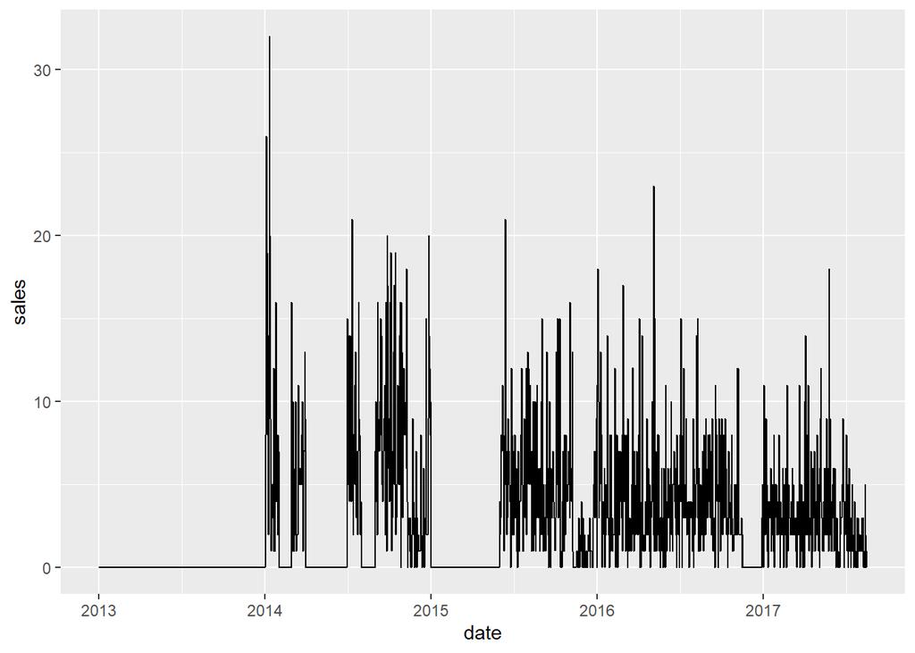

```r
train %>% filter(family=="LADIESWEAR",store_nbr==13) %>%
  ggplot(.,aes(x=ymd(date),y=sales))+
  geom_line()+
  xlab("date")
```

```r
train %>% filter(family=="LADIESWEAR",store_nbr==13) %>%
  filter(ymd(date)>ymd("2015-05-26")) %>%
  select(date,store_nbr,family,sales) %>%
  head(10)
```

```
##          date store_nbr     family sales
## 1  2015-05-27        13 LADIESWEAR     0
## 2  2015-05-28        13 LADIESWEAR     0
## 3  2015-05-29        13 LADIESWEAR     0
## 4  2015-05-30        13 LADIESWEAR     0
## 5  2015-05-31        13 LADIESWEAR     0
## 6  2015-06-01        13 LADIESWEAR     4
## 7  2015-06-02        13 LADIESWEAR     2
## 8  2015-06-03        13 LADIESWEAR     3
## 9  2015-06-04        13 LADIESWEAR     4
## 10 2015-06-05        13 LADIESWEAR     8
```

```r
train[ymd(train$date)<=ymd("2015-05-31") & train$store_nbr==13 & train$family=="LADIESWEAR","sales"] <- NA
```

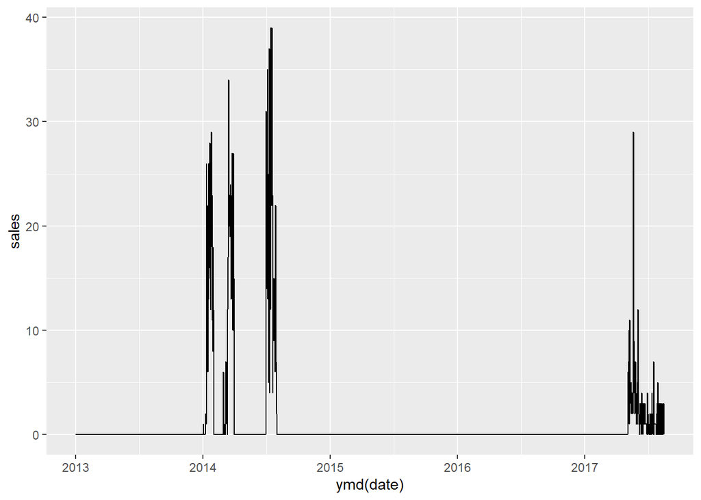

```r
train %>% filter(family=="LADIESWEAR",store_nbr==14) %>%
ggplot(.,aes(x=ymd(date),y=sales))+
  geom_line()
```

```r
train %>% filter(family=="LADIESWEAR",store_nbr==14) %>%
  filter(ymd(date)>ymd("2017-04-28")) %>%
  select(date,store_nbr,family,sales) %>%
  head(10)
```

```
##          date store_nbr     family sales
## 1  2017-04-29        14 LADIESWEAR     0
## 2  2017-04-30        14 LADIESWEAR     0
## 3  2017-05-01        14 LADIESWEAR     0
## 4  2017-05-02        14 LADIESWEAR     0
## 5  2017-05-03        14 LADIESWEAR     0
## 6  2017-05-04        14 LADIESWEAR     3
## 7  2017-05-05        14 LADIESWEAR     6
## 8  2017-05-06        14 LADIESWEAR     7
## 9  2017-05-07        14 LADIESWEAR    10
## 10 2017-05-08        14 LADIESWEAR     1
```

```r
train[ymd(train$date)<=ymd("2017-05-03") & train$store_nbr==14 & train$family=="LADIESWEAR","sales"] <- NA
```

## 5.9 Dropping Variables

The effects of the date variable is being replaced with the trend features. Transactions only exists in the train set and not the test set. Since we will model each family and store number combination independently they will exhibit the same city, state, type, and cluster in each model so will be dropped.

```r
train <- train %>%
  select(-date,-transactions,-city,-state,-type,-cluster)

test <- test %>%
  select(-date,-city,-state,-type,-cluster)
```

# 6 Pre-Processing

Strings will be converted to factors.

```r
train$month <- as.character(train$month)
test$month <- as.character(test$month)

for(name in names(train)){
  if(is.character(train[,name])){
    train[,name] <- as.factor(train[,name])
  }
}

for(name in names(test)){
  if(is.character(test[,name])){
    test[,name] <- as.factor(test[,name])
  }
}
```

## 6.1 Dummy Vars

```r
makeDummy <- dummyVars(~month+wday,data=train,fullRank = TRUE)
train2 <- predict(makeDummy,train)
train2 <- as.data.frame(train2)
train <- cbind(train[,-c(8,10)],train2)

test2 <- predict(makeDummy,test)
test2 <- as.data.frame(test2)
test <- cbind(test[,-c(8,10)],test2)

rm(train2,test2)
```

## 6.2 Standardization

```r
makeStandard <- preProcess(train[,c(4,5,6,7)],method=c("center","scale"))
train <- predict(makeStandard,train)

test <- predict(makeStandard,test)

gt(head(train))
```

[output not shown]

```r
write.csv(train,"trainCleaned.csv",row.names = FALSE)
write.csv(test,"testCleaned.csv",row.names = FALSE)
```

```r
train <- read.csv("trainCleaned.csv")
test <- read.csv("testCleaned.csv")
```

# 7 Modeling

The train control method used in our modeling phase is formed below. It uses the custom summary of rmsle which is the objective metric of Kaggle.

```r
custom_summary = function(data, lev = NULL, model = NULL) {
out = Metrics::rmsle(data[, "obs"], data[, "pred"])
names(out) = c("rmsle")
out
}


ctrl <- trainControl(method="cv",
                     number=5,
                     summaryFunction = custom_summary)
```

## 7.1 Elastic Net

The way the following for loop works is it loops over all the combinations of families and store numbers from the hasSales data frame. This is the data frame that contains all the combinations that we will not predict as zero.

At each iteration it will build an enet model and add it to a list. The value printed will be the average rmsle for all store numbers for each family present in the hasSales data frame.

```r
rm(enetModels)
enetModels <- list()
oneResult <- 0
results <- 0
counter <- 0

for(i in 1:nrow(hasSales)){
    families <- hasSales[i,1]
    stores <- hasSales[i,2]

    newTemp <- train[complete.cases(train),] %>%
      filter(family==families & store_nbr==stores)

    set.seed(147)
    enetMod <- train(sales~.,
                   data=newTemp[,-c(1,2)],
                   method="glmnet",
                   trControl=ctrl,
                   metric="rmsle",
                   maximize=FALSE)

    enetModels[[i]] <- enetMod
    oneResult <- min(enetMod$results$rmsle,na.rm=TRUE)
    results <- results+oneResult
    counter <- counter+1

    if(i==nrow(hasSales)){
      print(paste(families,round(results/counter,4)))
    }

    if(i!=nrow(hasSales) & families!=hasSales[i+1,1]){
      print(paste(families,round(results/counter,4)))
      counter <- 0
      results <- 0
    }
}
```

```r
rlist::list.save(enetModels,"enetModels1.rds")
```

```r
enetModels <- rlist::list.load("enetModels1.rds")
```

```r
modelingResults <- function(hasSalesDF){
  oneResult <- 0
  results <- 0
  counter <- 0
for(i in 1:nrow(hasSalesDF)){
  families <- hasSales[i,1]
    stores <- hasSales[i,2]

    oneResult <- min(enetModels[[i]]$results$rmsle,na.rm=TRUE)
    results <- results+oneResult
    counter <- counter+1

    if(i==nrow(hasSalesDF)){
      print(paste(families,round(results/counter,4)))
    }

    if(i!=nrow(hasSalesDF) & families!=hasSales[i+1,1]){
      print(paste(families,round(results/counter,4)))
      counter <- 0
      results <- 0
    }
}
}

modelingResults(hasSales)
```

```
## [1] "AUTOMOTIVE 0.5713"
## [1] "BABY CARE 0.3451"
## [1] "BEAUTY 0.5237"
## [1] "BEVERAGES 0.6264"
## [1] "BOOKS 0.392"
## [1] "BREAD/BAKERY 0.4686"
## [1] "CELEBRATION 0.9743"
## [1] "CLEANING 0.5256"
## [1] "DAIRY 0.5019"
## [1] "DELI 0.4396"
## [1] "EGGS 0.4914"
## [1] "FROZEN FOODS 0.5598"
## [1] "GROCERY I 0.5919"
## [1] "GROCERY II 0.6305"
## [1] "HARDWARE 0.5557"
```

[output cut: 18 more lines]

# 8 Feature Engineering 2

Some of the family RMSLE were very poor. They include celebration, home kitchen I, home kitchen II, home care, ladies wear, players and electronics, and produce. Looking at the charts all of these families exhibit some period where the sales were zero. In order to account for this all sales before the period where zero sales were made will be set to NA, causing them to be ignored in the second modeling phase.

**Celebration**

```r
# added to give identifier
hasSales$nrow <- seq(1,nrow(hasSales))

train$dates <- ymd(dates)

hasSales %>% filter(family=="CELEBRATION")
```

```
##         family store_nbr count nrow
## 1  CELEBRATION         1   685  284
## 2  CELEBRATION         2   672  285
## 3  CELEBRATION         3   668  286
## 4  CELEBRATION         4   675  287
## 5  CELEBRATION         5   668  288
## 6  CELEBRATION         6   670  289
## 7  CELEBRATION         7   668  290
## 8  CELEBRATION         8   668  291
## 9  CELEBRATION         9   674  292
## 10 CELEBRATION        10   771  293
## 11 CELEBRATION        11   668  294
## 12 CELEBRATION        12   673  295
## 13 CELEBRATION        13   709  296
## 14 CELEBRATION        14   699  297
```

[output cut: 40 more lines]

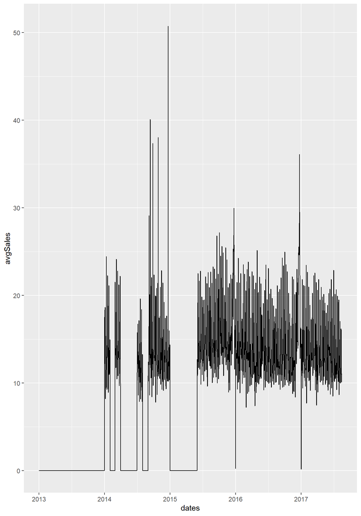

```r
celebrationMin <- min(hasSales %>% filter(family=="CELEBRATION") %>% select(nrow))
celebrationMax <- max(hasSales %>% filter(family=="CELEBRATION") %>% select(nrow))


train %>% filter(family=="CELEBRATION") %>%
  group_by(dates) %>%
  summarize(avgSales=mean(sales,na.rm=TRUE)) %>%
  ggplot(.,aes(x=dates,y=avgSales))+
  geom_line()
```

```r
train %>% filter(family=="CELEBRATION") %>%
  group_by(dates) %>% summarize(avgSales=mean(sales,na.rm=TRUE)) %>%
  filter(dates>ymd("2015-05-27")) %>%
  head(10)
```

```
## # A tibble: 10 × 2
##    dates      avgSales
##    <date>        <dbl>
##  1 2015-05-28      0
##  2 2015-05-29      0
##  3 2015-05-30      0
##  4 2015-05-31      0
##  5 2015-06-01     12.7
##  6 2015-06-02     10.8
##  7 2015-06-03     10.9
##  8 2015-06-04     14.1
##  9 2015-06-05     19.2
## 10 2015-06-06     22.5
```

```r
train[train$family=="CELEBRATION" & train$dates<=ymd("2015-05-31"),"sales"] <- NA
```

**HOME AND KITCHEN I**

For Home and Kitchen I sales a gap occurred before September 1, 2014. All observations before this date will be ignored.

```r
hasSales %>% filter(family=="HOME AND KITCHEN I")
```

```
##                family store_nbr count nrow
## 1  HOME AND KITCHEN I         1   526  770
## 2  HOME AND KITCHEN I         2   518  771
## 3  HOME AND KITCHEN I         3   518  772
## 4  HOME AND KITCHEN I         4   520  773
## 5  HOME AND KITCHEN I         5   518  774
## 6  HOME AND KITCHEN I         6   518  775
## 7  HOME AND KITCHEN I         7   522  776
## 8  HOME AND KITCHEN I         8   518  777
## 9  HOME AND KITCHEN I         9   518  778
## 10 HOME AND KITCHEN I        10   536  779
## 11 HOME AND KITCHEN I        11   518  780
## 12 HOME AND KITCHEN I        12   581  781
## 13 HOME AND KITCHEN I        13   529  782
## 14 HOME AND KITCHEN I        14   533  783
```

[output cut: 40 more lines]

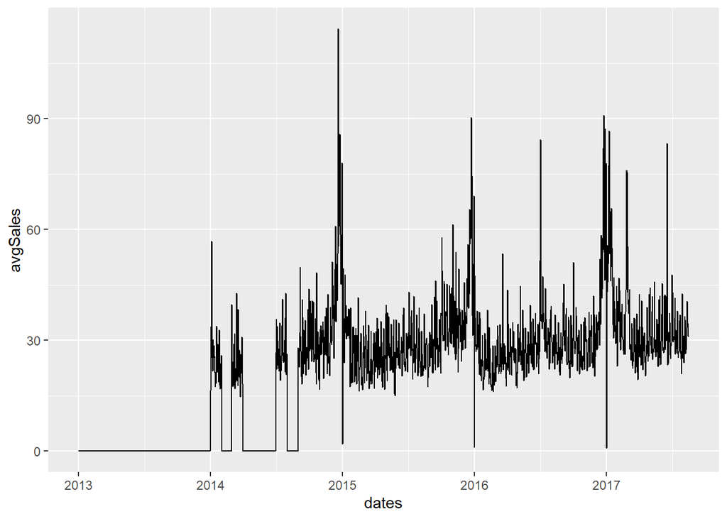

```r
homeKitchenIMin <- min(hasSales %>% filter(family=="HOME AND KITCHEN I") %>% select(nrow))
homeKitchenIMax <- max(hasSales %>% filter(family=="HOME AND KITCHEN I") %>% select(nrow))

train %>% filter(family=="HOME AND KITCHEN I") %>%
  group_by(dates) %>%
  summarize(avgSales=mean(sales,na.rm=TRUE)) %>%
  ggplot(.,aes(x=dates,y=avgSales))+
  geom_line()
```

```r
train %>% filter(family=="HOME AND KITCHEN I") %>%
  group_by(dates) %>% summarize(avgSales=mean(sales,na.rm=TRUE)) %>%
  filter(dates>ymd("2014-08-26")) %>%
  head(10)
```

```
## # A tibble: 10 × 2
##    dates      avgSales
##    <date>        <dbl>
##  1 2014-08-27      0
##  2 2014-08-28      0
##  3 2014-08-29      0
##  4 2014-08-30      0
##  5 2014-08-31      0
##  6 2014-09-01     28.0
##  7 2014-09-02     24.8
##  8 2014-09-03     27.0
##  9 2014-09-04     22.7
## 10 2014-09-05     32.0
```

```r
train[train$family=="HOME AND KITCHEN I" & train$dates<=ymd("2014-08-31"),"sales"] <- NA
```

**HOME AND KITCHEN II**

Home and Kitchen II has the same sales gap as Home and Kitchen I. Sales before September 1, 2014 will be ignored.

```r
hasSales %>% filter(family=="HOME AND KITCHEN II")
```

```
##                 family store_nbr count nrow
## 1  HOME AND KITCHEN II         1   531  824
## 2  HOME AND KITCHEN II         2   522  825
## 3  HOME AND KITCHEN II         3   518  826
## 4  HOME AND KITCHEN II         4   525  827
## 5  HOME AND KITCHEN II         5   518  828
## 6  HOME AND KITCHEN II         6   518  829
## 7  HOME AND KITCHEN II         7   519  830
## 8  HOME AND KITCHEN II         8   518  831
## 9  HOME AND KITCHEN II         9   518  832
## 10 HOME AND KITCHEN II        10   539  833
## 11 HOME AND KITCHEN II        11   518  834
## 12 HOME AND KITCHEN II        12   580  835
## 13 HOME AND KITCHEN II        13   519  836
## 14 HOME AND KITCHEN II        14   528  837
```

[output cut: 40 more lines]

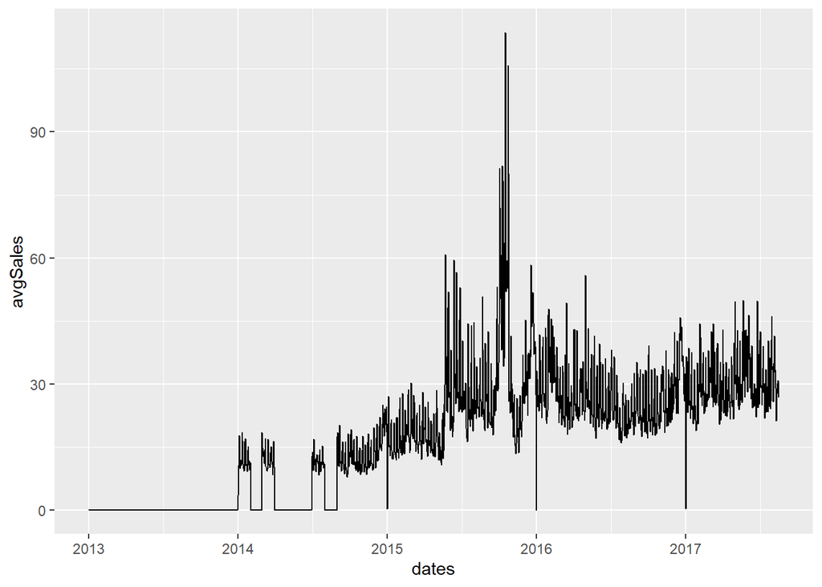

```r
homeKitchenIIMin <- min(hasSales %>% filter(family=="HOME AND KITCHEN II") %>% select(nrow))
homeKitchenIIMax <- max(hasSales %>% filter(family=="HOME AND KITCHEN II") %>% select(nrow))

train %>% filter(family=="HOME AND KITCHEN II") %>%
  group_by(dates) %>%
  summarize(avgSales=mean(sales,na.rm=TRUE)) %>%
  ggplot(.,aes(x=dates,y=avgSales))+
  geom_line()
```

```r
train %>% filter(family=="HOME AND KITCHEN II") %>%
  group_by(dates) %>% summarize(avgSales=mean(sales,na.rm=TRUE)) %>%
  filter(dates>ymd("2014-08-26")) %>%
  head(10)
```

```
## # A tibble: 10 × 2
##    dates      avgSales
##    <date>        <dbl>
##  1 2014-08-27      0
##  2 2014-08-28      0
##  3 2014-08-29      0
##  4 2014-08-30      0
##  5 2014-08-31      0
##  6 2014-09-01     17.5
##  7 2014-09-02     18.5
##  8 2014-09-03     13.6
##  9 2014-09-04     10.7
## 10 2014-09-05     10.4
```

```r
train[train$family=="HOME AND KITCHEN II" & train$dates<=ymd("2014-08-31"),"sales"] <- NA
```

**HOME CARE**

Any observations for Home Care before May 4, 2015 will be ignored because of a sales gap.

```r
hasSales %>% filter(family=="HOME CARE")
```

```
##       family store_nbr count nrow
## 1  HOME CARE         1   641  932
## 2  HOME CARE         2   641  933
## 3  HOME CARE         3   640  934
## 4  HOME CARE         4   640  935
## 5  HOME CARE         5   640  936
## 6  HOME CARE         6   640  937
## 7  HOME CARE         7   640  938
## 8  HOME CARE         8   640  939
## 9  HOME CARE         9   640  940
## 10 HOME CARE        10   640  941
## 11 HOME CARE        11   640  942
## 12 HOME CARE        12   665  943
## 13 HOME CARE        13   640  944
## 14 HOME CARE        14   650  945
```

[output cut: 40 more lines]

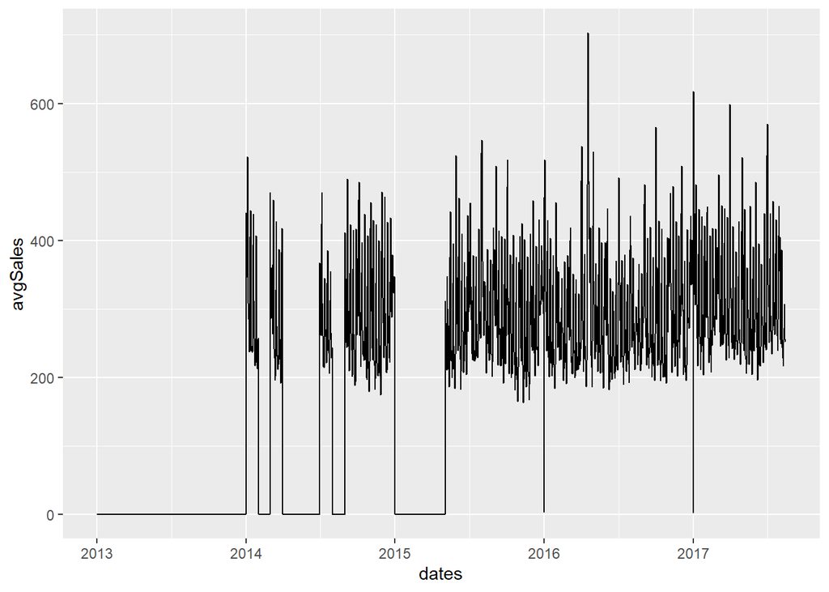

```r
homeCareMin <- min(hasSales %>% filter(family=="HOME CARE") %>% select(nrow))
homeCareMax <- max(hasSales %>% filter(family=="HOME CARE") %>% select(nrow))

train %>% filter(family=="HOME CARE") %>%
  group_by(dates) %>%
  summarize(avgSales=mean(sales,na.rm=TRUE)) %>%
  ggplot(.,aes(x=dates,y=avgSales))+
  geom_line()
```

```r
train %>% filter(family=="HOME CARE") %>%
  group_by(dates) %>% summarize(avgSales=mean(sales,na.rm=TRUE)) %>%
  filter(dates>ymd("2015-04-28")) %>%
  head(10)
```

```
## # A tibble: 10 × 2
##    dates      avgSales
##    <date>        <dbl>
##  1 2015-04-29       0
##  2 2015-04-30       0
##  3 2015-05-01       0
##  4 2015-05-02       0
##  5 2015-05-03       0
##  6 2015-05-04     312.
##  7 2015-05-05     280.
##  8 2015-05-06     264.
##  9 2015-05-07     213.
## 10 2015-05-08     211.
```

```r
train[train$family=="HOME CARE" & train$dates<=ymd("2015-05-03"),"sales"] <- NA
```

**LADIESWEAR**

Any sales before June 1, 2015 will be ignored.

```r
hasSales %>% filter(family=="LADIESWEAR")
```

```
##        family store_nbr count nrow
## 1  LADIESWEAR         1   674  986
## 2  LADIESWEAR         2   668  987
## 3  LADIESWEAR         3   671  988
## 4  LADIESWEAR         4   668  989
## 5  LADIESWEAR         5   670  990
## 6  LADIESWEAR         6   668  991
## 7  LADIESWEAR         7   673  992
## 8  LADIESWEAR         8   668  993
## 9  LADIESWEAR         9   669  994
## 10 LADIESWEAR        10   822  995
## 11 LADIESWEAR        11   671  996
## 12 LADIESWEAR        12  1386  997
## 13 LADIESWEAR        13   795  998
## 14 LADIESWEAR        14  1523  999
```

[output cut: 30 more lines]

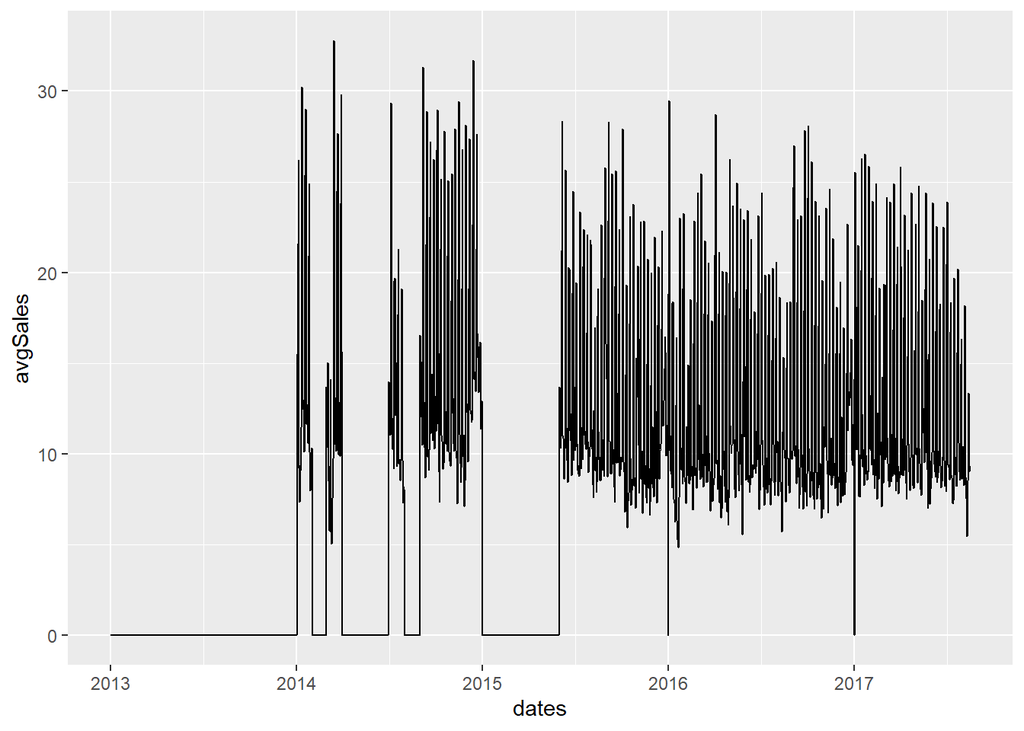

```r
ladieswearMin <- min(hasSales %>% filter(family=="LADIESWEAR") %>% select(nrow))
ladieswearMax <- max(hasSales %>% filter(family=="LADIESWEAR") %>% select(nrow))

train %>% filter(family=="LADIESWEAR") %>%
  group_by(dates) %>%
  summarize(avgSales=mean(sales,na.rm=TRUE)) %>%
  ggplot(.,aes(x=dates,y=avgSales))+
  geom_line()
```

```r
train %>% filter(family=="LADIESWEAR") %>%
  group_by(dates) %>% summarize(avgSales=mean(sales,na.rm=TRUE)) %>%
  filter(dates>ymd("2015-05-26")) %>%
  head(10)
```

```
## # A tibble: 10 × 2
##    dates      avgSales
##    <date>        <dbl>
##  1 2015-05-27      0
##  2 2015-05-28      0
##  3 2015-05-29      0
##  4 2015-05-30      0
##  5 2015-05-31      0
##  6 2015-06-01     12.5
##  7 2015-06-02     13.7
##  8 2015-06-03     12.1
##  9 2015-06-04     10.3
## 10 2015-06-05     11.5
```

```r
train[train$family=="LADIESWEAR" & train$dates<=ymd("2015-05-31"),"sales"] <- NA
```

**PLAYERS AND ELECTRONICS**

Any sales before June 1, 2015 will be ignored.

```r
hasSales %>% filter(family=="PLAYERS AND ELECTRONICS")
```

```
##                     family store_nbr count nrow
## 1  PLAYERS AND ELECTRONICS         1   682 1394
## 2  PLAYERS AND ELECTRONICS         2   674 1395
## 3  PLAYERS AND ELECTRONICS         3   668 1396
## 4  PLAYERS AND ELECTRONICS         4   676 1397
## 5  PLAYERS AND ELECTRONICS         5   671 1398
## 6  PLAYERS AND ELECTRONICS         6   669 1399
## 7  PLAYERS AND ELECTRONICS         7   671 1400
## 8  PLAYERS AND ELECTRONICS         8   668 1401
## 9  PLAYERS AND ELECTRONICS         9   669 1402
## 10 PLAYERS AND ELECTRONICS        10   718 1403
## 11 PLAYERS AND ELECTRONICS        11   668 1404
## 12 PLAYERS AND ELECTRONICS        12   712 1405
## 13 PLAYERS AND ELECTRONICS        13   735 1406
## 14 PLAYERS AND ELECTRONICS        14   712 1407
```

[output cut: 40 more lines]

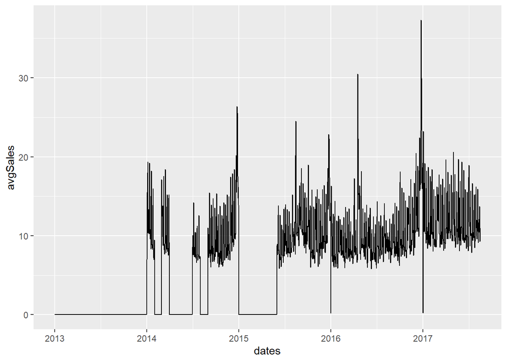

```r
playersElectronicsMin <- min(hasSales %>% filter(family=="PLAYERS AND ELECTRONICS") %>% select(nrow))
playersElectronicsMax <- max(hasSales %>% filter(family=="PLAYERS AND ELECTRONICS") %>% select(nrow))

train %>% filter(family=="PLAYERS AND ELECTRONICS") %>%
  group_by(dates) %>%
  summarize(avgSales=mean(sales,na.rm=TRUE)) %>%
  ggplot(.,aes(x=dates,y=avgSales))+
  geom_line()
```

```r
train %>% filter(family=="PLAYERS AND ELECTRONICS") %>%
  group_by(dates) %>% summarize(avgSales=mean(sales,na.rm=TRUE)) %>%
  filter(dates>ymd("2015-05-26")) %>%
  head(10)
```

```
## # A tibble: 10 × 2
##    dates      avgSales
##    <date>        <dbl>
##  1 2015-05-27     0
##  2 2015-05-28     0
##  3 2015-05-29     0
##  4 2015-05-30     0
##  5 2015-05-31     0
##  6 2015-06-01     8.33
##  7 2015-06-02     8.76
##  8 2015-06-03     8.94
##  9 2015-06-04     7.6
## 10 2015-06-05     8.1
```

```r
train[train$family=="PLAYERS AND ELECTRONICS" & train$dates<=ymd("2015-05-31"),"sales"] <- NA
```

**Produce**

Any sales before June 1, 2015 will be ignored.

```r
hasSales %>% filter(family=="PRODUCE")
```

```
##     family store_nbr count nrow
## 1  PRODUCE         1   175 1556
## 2  PRODUCE         2   147 1557
## 3  PRODUCE         3   107 1558
## 4  PRODUCE         4   125 1559
## 5  PRODUCE         5   112 1560
## 6  PRODUCE         6    85 1561
## 7  PRODUCE         7   108 1562
## 8  PRODUCE         8   266 1563
## 9  PRODUCE         9   668 1564
## 10 PRODUCE        10   668 1565
## 11 PRODUCE        11   668 1566
## 12 PRODUCE        12   668 1567
## 13 PRODUCE        13   668 1568
## 14 PRODUCE        14   678 1569
```

[output cut: 40 more lines]

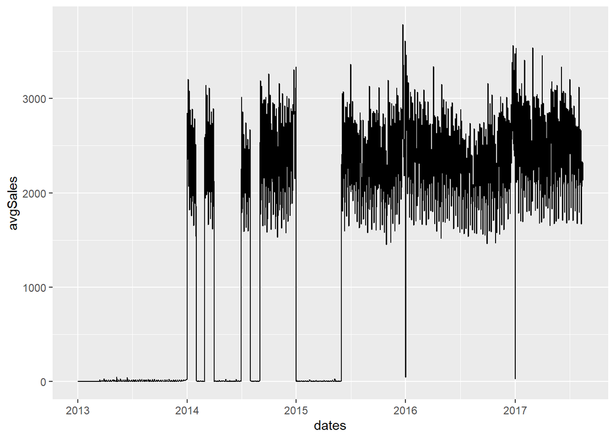

```r
produceMin <- min(hasSales %>% filter(family=="PRODUCE") %>% select(nrow))
produceMax <- max(hasSales %>% filter(family=="PRODUCE") %>% select(nrow))


train %>% filter(family=="PRODUCE") %>%
  group_by(dates) %>%
  summarize(avgSales=mean(sales,na.rm=TRUE)) %>%
  ggplot(.,aes(x=dates,y=avgSales))+
  geom_line()
```

```r
train %>% filter(family=="PRODUCE") %>%
  group_by(dates) %>%
  summarize(avgSales=mean(sales,na.rm=TRUE)) %>%
  filter(dates>ymd("2015-05-27")) %>%
  head(10)
```

```
## # A tibble: 10 × 2
##    dates      avgSales
##    <date>        <dbl>
##  1 2015-05-28     2.15
##  2 2015-05-29     7.56
##  3 2015-05-30    11.6
##  4 2015-05-31     6.29
##  5 2015-06-01  2305.
##  6 2015-06-02  2407.
##  7 2015-06-03  3056.
##  8 2015-06-04  1803.
##  9 2015-06-05  1948.
## 10 2015-06-06  2581.
```

```r
train[train$family=="PRODUCE" & train$dates<=ymd("2015-05-31"),"sales"] <- NA

train <- train %>% select(-dates)
```

# 9 Modeling 2

The families of Celebration, Home Kitchen I, Home Kitchen II, Home Care, Ladies wear, Players and Electronics, and Produce will be remodeled with the added NA values introduced. The rmsle decreased for all the families somewhat dramatically after the added feature engineering.

```r
oneResult <- 0
results <- 0
counter <- 0

for(i in c(c(celebrationMin:celebrationMax),c(homeKitchenIMin:homeKitchenIMax),c(homeKitchenIIMin:homeKitchenIIMax),c(homeCareMin:homeCareMax),c(ladieswearMin:ladieswearMax),c(playersElectronicsMin:playersElectronicsMax),c(produceMin:produceMax))){
    families <- hasSales[i,1]
    stores <- hasSales[i,2]

    newTemp <- train[complete.cases(train),] %>%
      filter(family==families & store_nbr==stores)

    set.seed(147)
    enetMod <- train(sales~.,
                   data=newTemp[,-c(1,2)],
                   method="glmnet",
                   trControl=ctrl,
                   metric="rmsle",
                   maximize=FALSE)

    enetModels[[i]] <- enetMod
    oneResult <- min(enetMod$results$rmsle,na.rm=TRUE)
    results <- results+oneResult
    counter <- counter+1

    if(i==nrow(hasSales)){
      print(paste(families,round(results/counter,4)))
    }

    if(i!=nrow(hasSales) & families!=hasSales[i+1,1]){
      print(paste(families,round(results/counter,4)))
      counter <- 0
      results <- 0
    }
}
```

```r
data.frame(family=c("Celebration","Home kitchen I","Home Kitchen II","Home Care","Ladies Wear","Players and Electronics","Produce"),without_feature_engineering=c(.9743,.9524,.8154,1.9594,.9862,.8258,2.6595),with_feature_engineering=c(.6035,.6521,.5976,.3897,.5818,.5285,.4088))
```

```
##                    family without_feature_engineering with_feature_engineering
## 1             Celebration                      0.9743                   0.6035
## 2          Home kitchen I                      0.9524                   0.6521
## 3         Home Kitchen II                      0.8154                   0.5976
## 4               Home Care                      1.9594                   0.3897
## 5             Ladies Wear                      0.9862                   0.5818
## 6 Players and Electronics                      0.8258                   0.5285
## 7                 Produce                      2.6595                   0.4088
```

```r
rlist::list.save(enetModels,"enetModels2.rds")
```

```r
enetModels <- rlist::list.load("enetModels2.rds")
```

## 9.1 Forming Predictions

Predictions will be made from each of our models on their respective store number and family in the test set.

```r
rm(testGroups)
testGroups <- list()

for(i in 1:nrow(hasSales)){

     tempTest <- test %>%
      filter(family==hasSales[i,1] & store_nbr==hasSales[i,2])

    testGroups[[i]] <- data.frame(id=tempTest$id,predict(enetModels[[i]],tempTest))

  i=i+1
}
length(testGroups)
```

```
## [1] 1717
```

These predictions will be made into a data frame.

```r
rm(unlisted)
unlisted <- unlist(testGroups)
output <- data.frame(id=unlisted[grepl("id",names(unlisted))],sales=unlisted[!grepl("id",names(unlisted))])

head(output)
```

```
##        id    sales
## 1 3000888 4.524687
## 2 3002670 4.523594
## 3 3004452 4.512398
## 4 3006234 3.774222
## 5 3008016 3.776009
## 6 3009798 4.525366
```

All family and store number combinations that did not make a sale will be given a prediction of 0.

```r
rm(testGroupsZeros)
testGroupsZeros <- list()

for(i in 1:nrow(noSales)){

     tempTest <- test %>%
      filter(family==noSales[i,1] & store_nbr==noSales[i,2])

    testGroupsZeros[[i]] <- data.frame(id=tempTest$id,sales=0)

  i=i+1
}
length(testGroupsZeros)
```

```
## [1] 65
```

The sales predictions and zero predictions will be combined and arranged by id.

```r
rm(unlisted2)
unlisted2 <- unlist(testGroupsZeros)
output2 <- data.frame(id=unlisted2[grepl("id",names(unlisted2))],sales=unlisted2[!grepl("id",names(unlisted2))])

finalOutput <- rbind(output,output2)
finalOutput <- finalOutput %>%
  arrange(id)

head(finalOutput)
```

```
##        id        sales
## 1 3000888    4.5246868
## 2 3000889    0.0000000
## 3 3000890    6.3859948
## 4 3000891 2215.8338574
## 5 3000892    0.1491077
## 6 3000893  419.2979209
```

# 10 Submission

The analysis is complete! All that is left to do is save the csv and submit.

```r
write.csv(finalOutput,file = "enetSubmission.csv",row.names=FALSE)
```

Rooms for Improvement:

- Only one model was chosen with minimal tuning applied. Different families could excel with different models, specifically the top selling families.
- The holidays data set was neglected completely. Having this would likely significantly boost the predictions of families such as the liquor, wine, and beer which displayed a very poor rmsle in the modeling phase.